# RNASeq Data Exploration, Normalization, and Identifier Mapping

DNA methylation in neurons from post-mortem brains in schizophrenia and bipolar disorder

Angela Uzelac

2023-02-14

# Introduction

A dopamine imbalance in the human brain is one of the factors central to the pathogenesis of major psychosis. A study done by Pai et al. suggests that epigenetic changes may increase dopamine synthesis and result in psychotic symptoms. Psychosis is a typical symptom observed in patients with Schizophrenia and Bipolar disease. Furthermore, abnormal DNA methylation has been detected in patients with Schizophrenia and bipolar disorder. One of the important experiments performed in this paper was profiling the transcriptomes of neuronal nuclei samples from post-mortem frontal cortex of individuals diagnosed with Schizophrenia or Bipolar disease, as well as controls. Sequencing was done using High-throughput RNASeq. The purpose of this experiment was to determine the consequences of altered DNA methylation in major psychosis(Pai et al. 2019).

With a future goal of investigating the differential expression across these genes, the purpose of this study was to gather the existing raw expression data, clean it up, normalize it, and convert to HGNC symbols since it is from human samples. All of these will set up this data to be easy to work with for future analyses. It is worthy to note that an expression dataset that was sequenced using Bulk RNASeq method was chosen because it provides good coverage of the sequences without taking up too much space on a computer.

This dataset was chosen as I am really interested in neuroscience and mental health, as well as epigenetics. A few years ago I learned that Schizophrenia has a genetic link, and since then I have wanted to study how it can arise and eventually find some potential therapeutics. The associated study was also easy to understand and was not a very big learning curve to understand how the experiment relates to the broader study.

## Initial set-up

Once the dataset GSE112523 was chosen, it was retrieved from GEO using the getGEO function from the R package GEOquery.

```r
# platform info

library(GEOquery)

gse <- getGEO("GSE112523", GSEMatrix = FALSE, getGPL= TRUE)
gpl <- names(GPLList(gse))[1]
gpl_info <- Meta(getGEO(gpl))
```

# Information about the platform GPL18573

Platform: Illumina NextSeq 500 (Homo sapiens)

Submission Date: Apr 15 2014

Last Updated: Mar 26 2019

Organism: Homo sapiens

Number of GEO datasets that use this technology: 9931

Number of GEO samples that use this technology: 291658

# Procedure and Results

## Downloading the raw expression data

First, gene count data was retrieved from the supplementary file provided in the GEO database, and read into an R dataframe object. Then, the total number of genes in the file was calculated.

```r
# get supplementary file from GEO
supp_files <- GEOquery::getGEOSuppFiles("GSE112523")
filenames <- rownames(supp_files)
# One supplemental file
# read supplementary file into dataframe
GSE112523 <- read.delim(filenames[1], sep = ",", header = TRUE, check.names = FALSE)

num_genes <- dim(GSE112523)[1]
```

Number of genes in the raw data: 58219

## Defining groups in the data

Since the goal of the experiment is to compare DNA methylation in neurons of individuals with a psychotic disorder (schizophrenia and bipolar) to those in undiagnosed individuals, the data was grouped into 2 groups: disease and control. As per the paper, there are 17 control samples and 17 case (disease) samples.

```r
#split data into 2 groups, control and disease

samples <- data.frame(lapply(colnames(GSE112523)[2:35],
        FUN=function(x){unlist(strsplit(x,
                        split = "_"))[c(1, 2)]}))
colnames(samples) <- colnames(GSE112523)[2:35]
rownames(samples) <- c("condition", "sample")
samples <- data.frame(t(samples))

samples$condition[which(grepl("^BIPOL", samples$condition))] <- "CASE"
samples$condition[which(grepl("^SCZ", samples$condition))] <- "CASE"
```

## Cleaning up duplicates

It was noticed that the number of genes in the raw data is far too large and is not biologically accurate. So, after some examination, it was noticed that some of the genes in the raw expression data appear more than once, and there are genes that are very weakly expressed and do not provide much information for the analysis. By removing the weakly expressed genes, the duplicate records were also removed, and the number of genes was brought down to a more reasonable and biologically possible number. The edgeR package protocol was followed such that genes with less than 1 read per million out of 17 samples are removed. Since there are 17 controls and 17 disease replicates, the lowest number of replicates is 17.

```r
# calculate number of duplicated genes
length(GSE112523[duplicated(GSE112523[,1]), 1])
```

```
## [1] 45
```

```r
# convert counts into counts per million
cpms <- edgeR::cpm(GSE112523[,2:35])
rownames(cpms) <- GSE112523[,1]
# get rid of genes that have low counts
# genes that have less than 1 read per million in 17 samples
sel <- rowSums(cpms > 1) >= 17
GSE112523_filtered <- GSE112523[sel,]
# now have 18079 genes, this is more realistic

#calculate number of duplicated genes after filtering
length(GSE112523_filtered[duplicated(GSE112523_filtered[,1]), 1])
```

```
## [1] 0
```

As the number of duplicated genes was reduced from 45 to 0, and the number of genes has decreased to 18079, it is clear that we have cleaner and more realistic data.

## Normalization

This study must account for numerous possibilities of technical variation in order to properly investigate the biological variation, i.e. the differential expression. First, the data was analyzed to determine what method of normalization is best to use, then a normalization method was applied and the differences were visualized.

### Analysis

First, the distribution of the data was visualized using a boxplot.

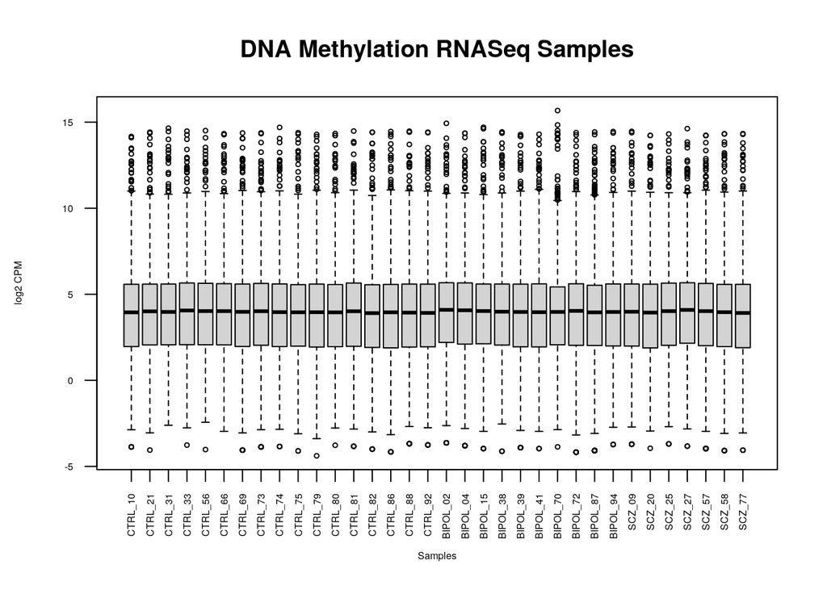

```r
# calculate the log of the counts per million and plot
logcpm <- log2(edgeR::cpm(GSE112523_filtered[,2:35]))
boxplot(logcpm, xlab = "Samples", ylab = "log2 CPM",
        las = 2, cex = 0.5, cex.lab = 0.5,
        cex.axis = 0.5, main = "DNA Methylation RNASeq Samples")
```

Most of the sample medians are close to the median line, showing some slight technical variation.

Next, a density function of the samples was plotted.

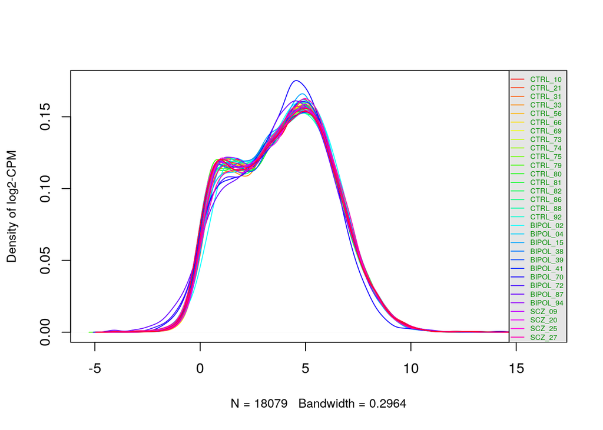

```r
# applies probability density function over columns (conditions) of log2 cpm values of the gene expression data
# the density across all genes for each sample
counts_density <- apply(logcpm, 2, density)

# calculate the limits across all the samples
xlim <- 0
ylim <- 0
for (i in 1:length(counts_density)) {
  xlim <- range(c(xlim, counts_density[[i]]$x));
  ylim <- range(c(ylim, counts_density[[i]]$y))
}
cols <- rainbow(length(counts_density))
# all line types to be solid (1)
line_type <- rep(1, length(counts_density))
# initialize the plot
plot(counts_density[[1]], xlim=xlim, ylim=ylim, type="n",
     ylab="Density of log2-CPM",
     main="", cex.lab = 0.85)
# plot each line
for (i in 1:length(counts_density)) {
  lines(counts_density[[i]], col=cols[i], lty=line_type[i])
}
# add a legend
legend("topright", colnames(logcpm),
       col=cols, lty=line_type, cex=0.5,
       border ="blue",  text.col = "green4",
       merge = TRUE, bg = "gray90")
```

From these two graphs, it is clear that the technical variation affected the disease and control samples in the same way. Therefore, normalization can be done by equilibrating expression levels from the non-differentially expressed genes. Since the exact expression levels and lengths of every gene are not known, it is not possible to estimate RNA production directly. However, a global fold change can be determined. The TMM strategy equates the overall expression levels of two samples under the assumption that most genes are not differentially expressed (Evans, Hardin, and Stoebel 2018). Essentially, the ratio between expression levels is looked at. Consequently, the TMM normalization method was used.

### Normalization

The data was normalized using the TMM method by applying several edgeR package functions. The function calcNormFactors normalizes the counts across the genes for each sample, which minimizes the log-fold changes between the samples. The results of the normalization were visualized in an MDS plot that shows the distances between samples.

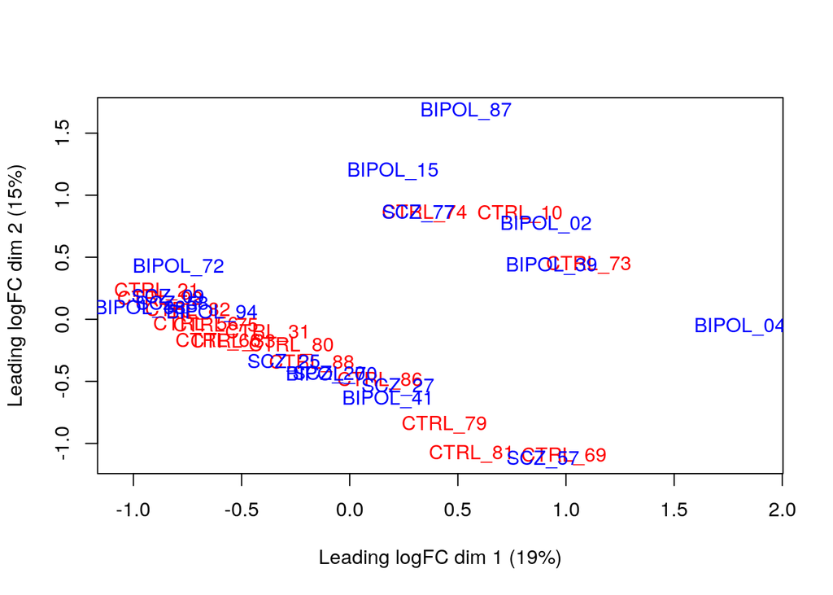

```r
#convert filtered data to matrix
data_as_matrix <- as.matrix(GSE112523_filtered[,2:35])
rownames(data_as_matrix) <- GSE112523_filtered[,1]
# convert to DGEList object so that the data can be used in further analyses using edgeR functions
dge <- edgeR::DGEList(counts=data_as_matrix, group=samples$condition)
# normalize the library size using TMM
dge_norm_fact <- edgeR::calcNormFactors(dge)
normalized_counts <- edgeR::cpm(dge_norm_fact)
# visualize sample separation by condition
limma::plotMDS(dge_norm_fact, labels=rownames(samples), col = c("blue", "red")[factor(samples$condition)])
```

Next, the variance of the sample from the mean is shown in a BCV plot. The common dispersion value for all genes is shown in red, the gene-specific dispersion is shown as black dots, and the general trend of variance is shown in blue. From this graph, it is clear that the genes with low expression have a high degree of variance, and as there is more expression, there is less variation between samples.

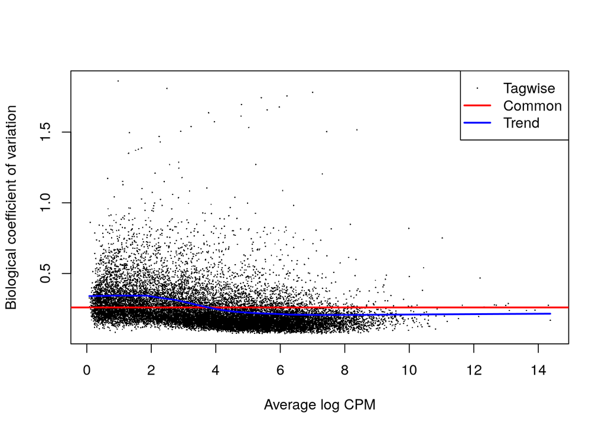

```r
# calculate dispersion
model_design <- model.matrix(~samples$condition)
disp <- edgeR::estimateDisp(dge_norm_fact, model_design)
# visualize the variation in the samples
edgeR::plotBCV(disp,col.tagwise = "black",col.common = "red")
```

## Identifier Mapping

Finally, the biomaRt package was used to convert the Ensembl gene IDs to HUGO symbols. A conversion stash was utilized to store the data retrieved from Ensembl Biomart so that the data does not have to be retrieved everytime if we already retrieved it. In the retrieval of the HGNC IDs, Ensembl gene IDs were used as the filter, and the desired attributes to be returned were Ensembl gene IDs and HGNC symbols. The table containing the mapped genes was then merged to the table of existing normalized expression counts.

```r
library(biomaRt)

# define which mart to use
ensembl <- useMart("ensembl")
# define which dataset to use
ensembl <- useDataset("hsapiens_gene_ensembl",mart=ensembl)

# store the conversion data so that the data does not have to be retrieved from Ensembl if it already exists
conversion_stash <- "GSE112523_id_conversion.rds"
if(file.exists(conversion_stash)){
  GSE112523_id_conversion <- readRDS(conversion_stash)
} else {
  GSE112523_id_conversion <- getBM(attributes = c("ensembl_gene_id","hgnc_symbol"),
                            filters = c("ensembl_gene_id"),
                            values = GSE112523_filtered[,1],
                            mart = ensembl)
  saveRDS(GSE112523_id_conversion, conversion_stash)
}

# merge table of normalized data with table of converted IDs
data_with_hgnc <- merge(GSE112523_id_conversion, normalized_counts, by.x = 1, by.y = 0, all.y = TRUE)
data_with_hgnc[c(1:5), c(1:5)]
```

```
##   ensembl_gene_id hgnc_symbol   CTRL_10   CTRL_21   CTRL_31
## 1 ENSG00000000003      TSPAN6  4.381282  6.597447  6.461319
## 2 ENSG00000000419        DPM1 19.008023 19.372503 15.103333
## 3 ENSG00000000457       SCYL3 14.424528 15.234104 14.780267
## 4 ENSG00000000460    C1orf112  5.796773  6.237586  6.703619
## 5 ENSG00000000938         FGR  2.156939  4.738166  3.149893
```

### Analyzing success of ID mapping

To determine the success of the ID mapping, the proportion of genes that were not mapped to HUGO symbols was calculated. Since only about 10% of ensembl genes were not mapped, they were removed from the data.

```r
# get ensembl ids that did not match to a HGNC symbol
ensembl_id_missing_hgnc <- data_with_hgnc$ensembl_gene_id[nchar(data_with_hgnc$hgnc_symbol) < 1 | is.na(data_with_hgnc$hgnc_symbol)]

# calculate the percentage of genes that did not map to HGNC symbols
num_missing = length(ensembl_id_missing_hgnc)
percent_missing = (num_missing/nrow(data_with_hgnc))*100
# 10.17%

# remove genes that did not map
data_with_hgnc <- data_with_hgnc[!(data_with_hgnc$ensembl_gene_id %in% ensembl_id_missing_hgnc), ]
```

Number of genes remaining in the data: 16240

Next, the number of genes that mapped to more than one HGNC symbol was calculated.

```r
# identify ensembl genes that mapped to more than 1 HGNC symbol
nrow(data_with_hgnc[duplicated(data_with_hgnc$ensembl_gene_id), c(1:2)])
```

```
## [1] 1
```

```r
duplicated_ensembl_id <- data_with_hgnc$ensembl_gene_id[duplicated(data_with_hgnc$ensembl_gene_id)]
data_with_hgnc[data_with_hgnc$ensembl_gene_id == duplicated_ensembl_id, c(1,2)]
```

```
##       ensembl_gene_id hgnc_symbol
## 14674 ENSG00000230417   LINC00595
## 14675 ENSG00000230417   LINC00856
```

It was discovered that only one Ensembl ID mapped to more than one HGNC symbol. Upon further searching in NCBI, it was determined that the different human genes were splice variants, as they had the same gene name (long intergenic non-protein coding RNA), they were on the same locus, but one of them has 2 exons and other has 3 exons.

Next, the number of genes that mapped to the same HGNC symbol was calculated, and it was found that there were no duplicated HGNC symbols.

```r
# identify ensembl genes that mapped to the same HGNC symbol
nrow(data_with_hgnc[duplicated(data_with_hgnc$hgnc_symbol), c(1:2)])
```

```
## [1] 0
```

# Conclusion

The final number of genes left in the data is 16240. This is a much cleaner set of expression values that do not contain duplicates or weakly expressed genes and are all mapped to HGNC symbols. The data was also normalized to account for technical variation. This data is ready for further processing and differential expression analysis.

Evans, Ciaran, Johanna Hardin, and Daniel M Stoebel. 2018. “Selecting Between-Sample RNA-Seq Normalization Methods from the Perspective of Their Assumptions.” *Briefings in Bioinformatics* 19 (5): 776–92.

Pai, Shraddha, Peipei Li, Bryan Killinger, Lee Marshall, Peixin Jia, Ji Liao, Arturas Petronis, Piroska E Szabó, and Viviane Labrie. 2019. “Differential Methylation of Enhancer at Igf2 Is Associated with Abnormal Dopamine Synthesis in Major Psychosis.” *Nature Communications* 10 (1): 2046.